# Hausarbeit Empirische Wirtschaftsforschung

Noe Kuhn

04/06/2022

### Library

```r
library(tidyverse)
library(ivreg)
library(AER)
```

## 1. David Card 1995 Replikation

```r
load("Card1995.RData")
D <- Card1995
dim(D)
```

```
## [1] 3010   18
```

### 1.1

*- Führen Sie eine univariate Regression mit log(wage) als abhängige und educ als erklärende* *Variable durch. Interpretieren Sie die Koefizienten und deren statistische Signifikanz.*

Ein univariates Modell der Bildungsrendite, geschätzt durch OLS, wird erstellt:

$$ln(wage) = \beta_0 + \beta_1educ + u$$

```r
D <- mutate(D,logwage = log(wage))

lm1.1 <- lm(logwage ~ educ, D)

summary(lm1.1)
```

```
##
## Call:
## lm(formula = logwage ~ educ, data = D)
##
## Residuals:
##      Min       1Q   Median       3Q      Max
## -1.73799 -0.27764  0.02373  0.28839  1.46080
##
## Coefficients:
##             Estimate Std. Error t value Pr(>|t|)
## (Intercept)  5.57088    0.03883  143.47   <2e-16 ***
## educ         0.05209    0.00287   18.15   <2e-16 ***
## ---
## Signif. codes:  0 '***' 0.001 '**' 0.01 '*' 0.05 '.' 0.1 ' ' 1
##
## Residual standard error: 0.4214 on 3008 degrees of freedom
## Multiple R-squared:  0.09874,    Adjusted R-squared:  0.09844
## F-statistic: 329.5 on 1 and 3008 DF,  p-value: < 2.2e-16
```

$\beta_1$: Der Regressionskoeffizient wird als statistisch sehr signifikant geschätzt. Hinzu ist der geschätzte Wert positiv (0.05), woraus geschlossen werden kann, dass mit jedem zunehmenden Bildungsjahr der Salär um ≈ 5.2% steigt.

$\beta_0$: Der Achsenabschnitt wird ebenso als statistisch sehr signifikant geschätzt. Interessanterweise ist er positiv, woraus eruiert werden kann, dass ein positiver Lohn auch erwartet werden kann ohne/ mit minimaler Bildung.

### 1.2

*- Warum schätzt die univariate Regression höchstwahrscheinlich keinen kausalen Effekt?* *Welche Art von Endogenität liegt hier vermutlich vor? Geben Sie zwei konkrete Beispiele.*

Ein Endogenitätsproblem eines Modell führt zu einer limitierten kausalen Ausagekraft. Zwei Arten von Endogenität könnten hier bestehen:

Reverse Causality: Diese Begrüdnung ist wahrscheinlich nicht gütlig, da das momentane Salär nicht die vergangene (und vermutlich abgeschlossene) Bildung beeinflussen kann. Also geht die Kausalität in die andere Richtung.

Verzerrung durch ausgelassene Variablen: Diese Art von Endogenität scheint sehr plausibel. Viele weitere Einflüsse bestimmen den Salär. Wenn diese Einflüsse noch hinzu einen Einfluss auf $educ$ haben, dann korreliert der Fehlerterm $u$ mit $educ$ und somit ist die Exogenitätsannahme MLR. 4 verletzt: $E(u|x_1) ≠ 0$ ! Zum Beispiel ist intrinsische “Fähigkeit”/“Talent” ebenso relevant für die Anzahl an Bildunsjahre sowie für den Lohn. Neben meritokratischen Bedingungen können äuserre Einflüsse wie Makroökonomische Bedingungen oder Diskrimination/Förderung ebenso den Lohn und die Bildungsjahre.

### 1.3

*- Spezifizieren Sie im nächsten Schritt ein Modell mit Kontrollvariablen. Sie dürfen (müssen* *aber nicht) sämtliche verfügbaren Variablen mit Ausnahme von nearc4 verwenden. Kommentieren* *Sie kurz die Auswahl ihrer Kontrollvariablen und mögliche Trade-offs in der* *Auswahl.*

Bei der Auswahl von weiteren Kontrollvariablen werden folgende Kriterien evaluiert

1. Die vermutete Signifikanz der Variablen soll hoch sein,
2. Verzerrung durch ausgelassene Variablen soll minimiert werden,
3. Zugleich soll die Varianz/Effizienz nicht explodieren aufgrund zu vielen Variablen Tradeoff Accuracy vs. Precision,
4. Schlussendlich soll keine perfekte Kolinearität zwischen Variablen bestehen.
5. Verfügbarkeit & Messbarkeit

In Casu:

1. Alle Variablen ausser $reg66X$ werden eingefügt, da unklar ist, welche Regionen behandelt werden und welche weshalb nicht.
2. Die restlichen Variablen scheinen einflussreich zu sein (Siehe Beispiele **1.2**)
3. Mit 3010 (**1.**) Beobachtungen haben wir genug Daten für die Anzahl Variablen.
4. Es gibt eine perfekte Kolinearität zwischhen $educ + exper + 6$ und $age$:

```r
sum(D$age == D$educ + D$exper + 6) == 3010
```

```
## [1] TRUE
```

5. IQ ist für ein Drittel der Beobachtungen nicht verfügbar und wird auch ausgelassen:

```r
sum(is.na(D$IQ))/3010
```

```
## [1] 0.3152824
```

Gerne hätte ich noch eine Interaktionsterm der Art $IQ * exper * educ$ hinzugefügt, jedoch wurden zwei dieser Variablen aussortiert. Der Interaktionsterm $black * south66$ könnte aber noch interessante Aussagen generieren über den Unterschied der Rassendiskriminerung im Norden Süden.

Somit besteht folgendes Modell:

$$ln(wage) = \beta_0+\beta_1educ+\beta_2black+\beta_3south66+\beta_4smsa66+\beta_5exper + \beta_6south66 * black$$

### 1.4

*- Schätzen Sie ein multivariates Regressionsmodell mit den zuvor ausgewählten Kontrollvariablen.* *Interpretieren Sie den Koeffzienten von educ. Vergleichen Sie das Resultat mit* *der univariaten Regression aus Teilaufgabe 1.1*

```r
lm1.4 <- lm(logwage ~ educ + black + south66 + smsa66 + exper + south66*black, D)

summary(lm1.4)
```

```
##
## Call:
## lm(formula = logwage ~ educ + black + south66 + smsa66 + exper +
##     south66 * black, data = D)
##
## Residuals:
##     Min      1Q  Median      3Q     Max
## -1.6288 -0.2308  0.0246  0.2496  1.3134
##
## Coefficients:
##                Estimate Std. Error t value Pr(>|t|)
## (Intercept)    4.921207   0.064096  76.778  < 2e-16 ***
## educ           0.076111   0.003581  21.254  < 2e-16 ***
## black         -0.107919   0.033806  -3.192  0.00143 **
## south66       -0.082220   0.017733  -4.637 3.69e-06 ***
## smsa66         0.109057   0.015348   7.105 1.49e-12 ***
## exper          0.038104   0.002229  17.092  < 2e-16 ***
## black:south66 -0.096137   0.040222  -2.390  0.01690 *
## ---
## Signif. codes:  0 '***' 0.001 '**' 0.01 '*' 0.05 '.' 0.1 ' ' 1
##
## Residual standard error: 0.3828 on 3003 degrees of freedom
## Multiple R-squared:  0.2576, Adjusted R-squared:  0.2561
## F-statistic: 173.7 on 6 and 3003 DF,  p-value: < 2.2e-16
```

$\beta_0$ bleibt immernoch sehr signifikant und weist die gleiche Interpretation wie zuvor aus

$\beta_1$ bleibt ebenso signifikant, jedoch wurde der Wert noch grösser. Dies daran, dass nun viele negative Einflüsse wie south und black miteinberechnet werden, also wurde $\beta_1$ zuvor unterschätzt. $\beta_6$ des Interaktionterms bestätigt interessanterweise, auch “nur” signifikant auf einem 95% Konfidenzinterval, die traurige Annahme aus **1.3**.

### 1.5

*- Welche Annahmen muss eine Instrumentalvariable erfüllen? Sind die Annahmen testbar?*

Die Instrumental Variabel (z) muss folgende zwei Annahmen treffen:

1. Relevanz: Die Kovarianz der IV und der ersetzten Variabel (x) ist ungleich 0 $Cov(x,z) ≠ 0$ $\rightarrow$ Die Varianz von x soll durch z erklärt werden.
2. Exogenität: Kovarianz der IV und dem Fehlerterm (u) ist gleich 0 $Cov(u,z) = 0$ $\rightarrow$ dies kann jedoch nicht berechnet werden und kann nur qualitativ argumentiert werden!

Zusätzlich soll die Instrumentalvariabel nur einen indirekten Einfluss auf die erklärte Variabel haben durch ihren Einfluss auf die endogene Variabel (Vorlesung 16, Slide 14)

### 1.6

*- Ist nearc4 eine valide Instrumentalvariable für educ? Diskutieren Sie, ob nearc4 Ihre zuvor* *genannten Annahmen erfüllt. Testen Sie diese Annahmen, wenn möglich. Falls Sie* *zum Schluss kommen, dass eine/mehrere Ihrer Annahmen verletzt ist/sind, erklären Sie* *weshalb.*

1. Relevanz

```r
var(x = D$nearc4, y = D$educ)
```

```
## [1] 0.179836
```

Wir können diese Annahme jedoch noch weiter testen, indem ein ANOVA test durchführen, in dem eine beschränkte Hilfsregression auf X mit einer unbeschränkten Hilfsregression mit z verglichen wird.

```r
hilfreg_lim <- lm(data = D, educ ~ black + south66 + smsa66 + reg661 + reg662 + reg662 + reg663 + reg664 +
                    reg665 + reg666 + reg667 + reg668 + reg669 + exper + IQ)

hilfreg_unlim <- lm(data = D, educ ~ black + south66 + smsa66 + reg661 + reg662 + reg662 + reg663 + reg664 +
                    reg665 + reg666 + reg667 + reg668 + reg669 + exper + IQ + nearc4)

anova(hilfreg_lim, hilfreg_unlim)
```

|  | Res.Df | RSS | Df | Sum of Sq | F | Pr(>F) |
| --- | --- | --- | --- | --- | --- | --- |
| 1 | 2048 | 5752.605 | NA | NA | NA | NA |
| 2 | 2047 | 5714.039 | 1 | 38.56603 | 13.81591 | 0.0002070346 |

Der Output bestätigt ebenfalls, dass nearc4 einen signifikanten Einfluss auf educ hat.

2. Exogenität

Diese Annahme kann in der Realität nie getroffen werden, da immer noch weitere Variablen den DGP mitbestimmen. Zum Beispiel ist das Einkommen des Elternhauses auch sehr relevant für die Nähe zu einem College sowie für den Lohn. Wenn wir die Ortschaften sowie die restlichen Variablen inkludieren, haben wir wahrscheinlich bereits die grösste Korrelation mit dem Fehlerterm eliminiert und bekommen dennoch keine zu grosse Varianz.

### 1.7

*- Schätzen Sie den Effekt von educ auf log(wage), indem Sie nearc4 als Instrument benutzen.* *Einmal ohne Kontrollvariablen und einmal mit den Kontrollvariablen aus Teilaufgabe* *3. Interpretieren Sie die Ergebnisse. Wie gross ist der Unterschied zu den Regressionen* *aus Teilaufgaben 1.1 und 1.4? Welches Resultat erscheint Ihnen am glaubwürdigsten und* *warum?*

1. Ohne weitere Kontrollvariablen, 2 Stage Least Squares.

```r
lm1.7.1 <- ivreg(data = D, logwage ~ educ | nearc4)
```

2. Mit Kontrollvariablen aus **1.4**

```r
lm1.7.2 <- ivreg(data = D, logwage ~ educ + black + south66 + smsa66 + exper + south66*black | nearc4 +
                   black + south66 + smsa66 + exper + south66*black)
```

Output:

```r
summary(lm1.7.1)
```

```
##
## Call:
## ivreg(formula = logwage ~ educ | nearc4, data = D)
##
## Residuals:
##      Min       1Q   Median       3Q      Max
## -2.24604 -0.36219  0.01269  0.37938  2.25907
##
## Coefficients:
##             Estimate Std. Error t value Pr(>|t|)
## (Intercept)  3.76747    0.34886  10.799  < 2e-16 ***
## educ         0.18806    0.02629   7.153 1.06e-12 ***
## ---
## Signif. codes:  0 '***' 0.001 '**' 0.01 '*' 0.05 '.' 0.1 ' ' 1
##
## Residual standard error: 0.5569 on 3008 degrees of freedom
## Multiple R-Squared: -0.5739, Adjusted R-squared: -0.5744
## Wald test: 51.17 on 1 and 3008 DF,  p-value: 1.061e-12
```

```r
summary(lm1.7.2)
```

```
##
## Call:
## ivreg(formula = logwage ~ educ + black + south66 + smsa66 + exper +
##     south66 * black | nearc4 + black + south66 + smsa66 + exper +
##     south66 * black, data = D)
##
## Residuals:
##      Min       1Q   Median       3Q      Max
## -1.95881 -0.26062  0.02252  0.27119  1.45633
##
## Coefficients:
##               Estimate Std. Error t value Pr(>|t|)
## (Intercept)    3.51713    0.94323   3.729 0.000196 ***
## educ           0.15902    0.05568   2.856 0.004321 **
## black         -0.03269    0.06234  -0.524 0.600026
## south66       -0.04919    0.02933  -1.677 0.093610 .
## smsa66         0.07654    0.02743   2.791 0.005290 **
## exper          0.07133    0.02239   3.186 0.001459 **
## black:south66 -0.09621    0.04366  -2.203 0.027644 *
## ---
## Signif. codes:  0 '***' 0.001 '**' 0.01 '*' 0.05 '.' 0.1 ' ' 1
##
## Residual standard error: 0.4155 on 3003 degrees of freedom
## Multiple R-Squared: 0.1251,  Adjusted R-squared: 0.1233
## Wald test: 84.83 on 6 and 3003 DF,  p-value: < 2.2e-16
```

Somit können wir die Bildungsrendite in der folgenden Tabelle zusammenfassen (Gerundet auf 3 Kommastelle):

Geschätzter Wert, 1 Reihe Ohne IV, **2 Reihe mit IV**:

|  | Beschr. Modell | Unb. Modell |
| --- | --- | --- |
| 1 | 0.052 | 0.076 |
| 2 | 0.188 | 0.159 |

Signifikanz (P Wert), 1. Reihe ohne IV, **2 Reihe mit IV**:

|  | Beschr. Modell | Unb. Modell |
| --- | --- | --- |
| 1 | 0 | 0.000 |
| 2 | 0 | 0.004 |

Die Steigerung von $\beta_1$ mit IV im beschränkten Modell kommt daher, dass $nearc4$ einen grösseren marginalen Einfluss auf logwage als $educ$ hat. Das gleiche gilt daher für den Übergang von unbeschränkten Modell ohne IV zu demjenigen mit IV.

```r
lm1.7.3 <- lm(data = D, logwage ~ nearc4)
lm1.7.3$coefficients[2]
```

```
##    nearc4
## 0.1559075
```

```r
lm1.7.3$coefficients[2] > lm1.1$coefficients[2]
```

```
## nearc4
##   TRUE
```

In Betracht der Glaubwürdigkeit würde ich das unbeschränkte Modell ohne IV als das Modell bezeichnen, dass am meisten dem wahren DGP gleicht, was auch im besten R^2 sichtbar ist. Um die Bildungsrendite am glaubwürdigsten zu ergreifen, soll dass unbeschränkte Model mit IV verwendet werden, da es den OVB und zugleich das Exogenitätsproblem von $educ$ behandelt. Zudem wirkt eine Bildungsrendite von ca. 16% am glaubwürdigsten, und wahrscheinlich sinkt diese weiter wenn weitere Variablen hinzugefügt werden. Zusammenfassend werde ich somit gerne viele weitere Jahre an der Universität St. Gallen verbringen.

## 2. Simulation IV

#### Definiere Grösse der Stichprobe und Parameter

```r
set.seed(1234)
n <- 3000
pi1 <- 1
b0 <- 6
b1 <- 1/10
b2 <- 1/100
b3 <- 1/2

# Ziehe Instrument
z <- rbinom(n,1,0.7)

# Ziehe Omitted Variable
ov <- rnorm(n,0,1)

# Generiere endogene Variable
d <- 12 + pi1 * z + 1/2 * ov + rnorm(n,0,2)

# Generiere abh?ngige Variable
y <- b0 + b1 * d + b2 * z + b3 * ov + rnorm(n,0,1/2)
```

### 2.1

*Ist z in diesem DGP eine valide Instrumentalvariable? Nutzen Sie sowohl formale Argumente,* *als auch die synthetische Stichprobe von Simulation.R für Ihre Argumentation.*

Siehe die zwei Annahmen für eine valide IV in **1.5**: 1. Relevanz und 2. Exogenität.

1. Annahme angenommen:

```r
var(x = z, y = d)
```

```
## [1] 0.1806705
```

Ferner könnte nochmals ein ANOVA Testferfahren wie bei *1.6* durchgeführt werden, jedoch reicht der oben gegebene Beweis aufgrund der Einfachheit des DGP. Der Faktor $\pi = 1$ beweist die Verbindung.

2. Die Exogenität kann hier formal begründet werden. Im DGP ist $z$ unabhängig vom Fehlerterm `rnorm(n,0,1/2` *Jedoch* wird $y$ hier *direkt* von $\beta_2z$ beeinflusst, also ist $z$ dennoch keine korrekte IV obwohl alle formalen Annahmen zutreffen.

## 2.2

*Zeigen Sie die Ergebnisse der OLS Regression* $y* =\beta_0 + \beta_1d + v$*. Wie gross ist die Abweichung* *vom wahren Wert?*

```r
lm2.2 <- lm(y ~ d)
summary(lm2.2)
```

```
##
## Call:
## lm(formula = y ~ d)
##
## Residuals:
##      Min       1Q   Median       3Q      Max
## -2.28477 -0.46859  0.00273  0.46260  2.11289
##
## Coefficients:
##             Estimate Std. Error t value Pr(>|t|)
## (Intercept) 5.300973   0.078290   67.71   <2e-16 ***
## d           0.156187   0.006072   25.72   <2e-16 ***
## ---
## Signif. codes:  0 '***' 0.001 '**' 0.01 '*' 0.05 '.' 0.1 ' ' 1
##
## Residual standard error: 0.6912 on 2998 degrees of freedom
## Multiple R-squared:  0.1808, Adjusted R-squared:  0.1805
## F-statistic: 661.7 on 1 and 2998 DF,  p-value: < 2.2e-16
```

Abweichung zum wahren $\beta_1$:

```r
as.numeric(lm2.2$coefficients[2]) - b1
```

```
## [1] 0.05618678
```

$y*$ hat somit einen formale Differenz von $\beta_2z + \beta_3ov + u + v$

### 2.3

*Zeigen Sie die Ergebnisse der IV Regression, in der Sie z als Instrument für d verwenden.* *Wie gross ist die Abweichung vom wahren Wert?*

```r
lm2.3 <- ivreg(y ~ d |z )
summary(lm2.3)
```

```
##
## Call:
## ivreg(formula = y ~ d | z)
##
## Residuals:
##       Min        1Q    Median        3Q       Max
## -2.257313 -0.457825  0.002189  0.465483  2.073776
##
## Coefficients:
##             Estimate Std. Error t value Pr(>|t|)
## (Intercept)  5.11228    0.40532  12.613  < 2e-16 ***
## d            0.17101    0.03183   5.372 8.39e-08 ***
## ---
## Signif. codes:  0 '***' 0.001 '**' 0.01 '*' 0.05 '.' 0.1 ' ' 1
##
## Residual standard error: 0.6919 on 2998 degrees of freedom
## Multiple R-Squared: 0.1792,  Adjusted R-squared: 0.1789
## Wald test: 28.86 on 1 and 2998 DF,  p-value: 8.387e-08
```

Abweichung zum wahren $\beta_1$:

```r
as.numeric(lm2.3$coefficients[2]) - b1
```

```
## [1] 0.07101397
```

### 2.4

*Berechnen Sie explizit (also ohne Packages) die 95%-Konfidenzintervalle für* $\beta_1*$ *aus Teilaufgaben* *2.2 und 2.3. Überprüfen Sie, ob der wahre Wert von* $\beta_1$ *innerhalb des Intervalls* *liegt.*

Der kritische Wert für ein 95% Konfidenzintervall wird mit qt() berechnet, *two tailed*:

```r
c <- qt(0.975, df = (3000-2))
c
```

```
## [1] 1.960756
```

Somit müssen für den Konfidenzintervall die Standard Fehler festgelegt werden und jene +/- c-Mal die Schätzung gerechnet werden

```r
se2.2 <- coef(summary(lm2.2))[, "Std. Error"]
se2.2 <- as.numeric(se2.2[2])
est2.2 <- as.numeric(lm2.2$coefficients[2])


se2.3 <- coef(summary(lm2.3))[, "Std. Error"]
se2.3 <- as.numeric(se2.3[2])
est2.3 <- as.numeric(lm2.3$coefficients[2])

conf2.2 <- c(est2.2 - c * se2.2, est2.2 + c * se2.2)
conf2.3 <- c(est2.3 - c * se2.3, est2.3 + c * se2.3)
```

$\beta_1$ liegt nicht im 95% Interval der OLS Regression:

```r
conf2.2[1] <= b1 & b1 <= conf2.2[2]
```

```
## [1] FALSE
```

$\beta_1$ liegt nicht im 95% Intervall der IV Regression:

```r
conf2.3[1] <= b1 & b1 <= conf2.3[2]
```

```
## [1] FALSE
```

### 2.5

*Analysieren Sie in einer Simulationsstudie, wie die Verzerrung und die Coverage Rate* *(95%) des IV-Schätzers mit der Stärke des Instruments variiert. Implementieren Sie dazu* *folgende Schritte:*

*- Schreiben Sie einen Loop, in dem der DGP gleich bleibt, nur dass sich* $\pi_1$ *von 1 auf* *0.1 in Schritten von 0.01 verringert*

*- Ziehen Sie fur jeden Wert von* $\pi_1$ *1000 Stichproben (benötigt normalerweise einen* *Loop im Loop) und berechnen Sie Verzerrung und Coverage Rate (95%) des OLS* *und IV-Schatzers für jeden* $\pi_1$*-Wert.*

*- Stellen Sie die Verzerrung und Coverage Rate der beiden Schätzer in Abhängigkeit* *von* $\pi_1$ *in geeigneten Grafiken dar.*

*- Erklären Sie Ihre Ergebnisse anhand formaler Argumente.*

Parameter:

```r
nsims <- 1000

pi <- seq(from = 1, to = 0.1, by = -0.01)
```

`nsims` bestimmt die Anzahl Stichproben pro $\pi$. Bei 1000 braucht die Berechnung relativ lange.

“Gedächtnis”:

```r
sumOLS <- 0
sumIV <- 0
sumBiasOLS <- 0
sumBiasIV <- 0
sumSEOLS <- 0
sumSEIV <- 0

totESTiv <- vector(mode = "numeric", length = 91)
totESTols <- vector(mode = "numeric", length = 91)

totBiasIV <- vector(mode = "numeric", length = 91)
totBiasOLS <- vector(mode = "numeric", length = 91)

covgrateIV <- vector(mode = "numeric", length = 91)
covgrateOLS <- vector(mode = "numeric", length = 91)

totSEIV <- vector(mode = "numeric", length = 91)
totSEOLS <- vector(mode = "numeric", length = 91)
```

Simulation:

```r
for (i in 1:91) {

  sumOLS <- vector()
  sumIV <- vector()
  sumBiasOLS <- vector()
  sumBiasIV <- vector()
  HitIV <- vector()
  HitOLS <- vector()
  sumSEOLS <- vector()
  sumSEIV <- vector()

  for(j in 1:nsims) {
    z <- rbinom(n,1,0.7)
    ov <- rnorm(n,0,1)
    d <- 12 + pi[i] * z + 1/2 * ov + rnorm(n,0,2)
    y<- b0 + b1 * d + b2 * z + b3 * ov + rnorm(n,0,1/2)

    lm5.2ols <- lm(y ~ d )
    lm5.2iv <- ivreg(y ~ d| z )

    ESTols <- as.numeric(lm5.2ols$coefficients[2])
    ESTiv <- as.numeric(lm5.2iv$coefficients[2])

    BIASols <- ESTols - b1
    BIASiv <- ESTiv - b1

    SEols <- coef(summary(lm5.2ols))[, "Std. Error"]
    SEols <- as.numeric(SEols[2])
    ESTols <- as.numeric(lm5.2ols$coefficients[2])

    SEiv <- coef(summary(lm5.2iv))[, "Std. Error"]
    SEiv <- as.numeric(SEiv[2])
    ESTiv <- as.numeric(lm5.2iv$coefficients[2])



    sumOLS[j] <- ESTols
    sumIV[j] <-  ESTiv
    sumBiasOLS[j] <- BIASols
    sumBiasIV[j] <- BIASiv
    HitIV[j] <- ifelse(ESTiv - 1.96 * SEiv <= b1  & b1 <= ESTiv + 1.96 * SEiv, 1, 0 )
    HitOLS[j] <- ifelse(ESTols - 1.96 * SEols <= b1 & b1 <= ESTols + 1.96 * SEols, 1, 0 )
    sumSEOLS[j] <- SEols
    sumSEIV[j] <- SEiv


  }

  totESTols[i]<- mean(sumOLS)
  totESTiv[i]<- mean(sumIV)
  totBiasIV[i] <- mean(sumBiasIV)
  totBiasOLS[i] <- mean(sumBiasOLS)
  covgrateIV[i] <- mean(HitIV)
  covgrateOLS[i] <- mean(HitOLS)
  totSEIV[i] <- mean(sumSEIV)
  totSEOLS[i] <- mean(sumSEOLS)
}
```

Data Frames erstellen mit den Resultaten:

```r
tab <- as_tibble(cbind(pi, totBiasIV,totBiasOLS))
tab2 <- as_tibble(cbind(pi, covgrateIV,covgrateOLS))
```

Graphen:

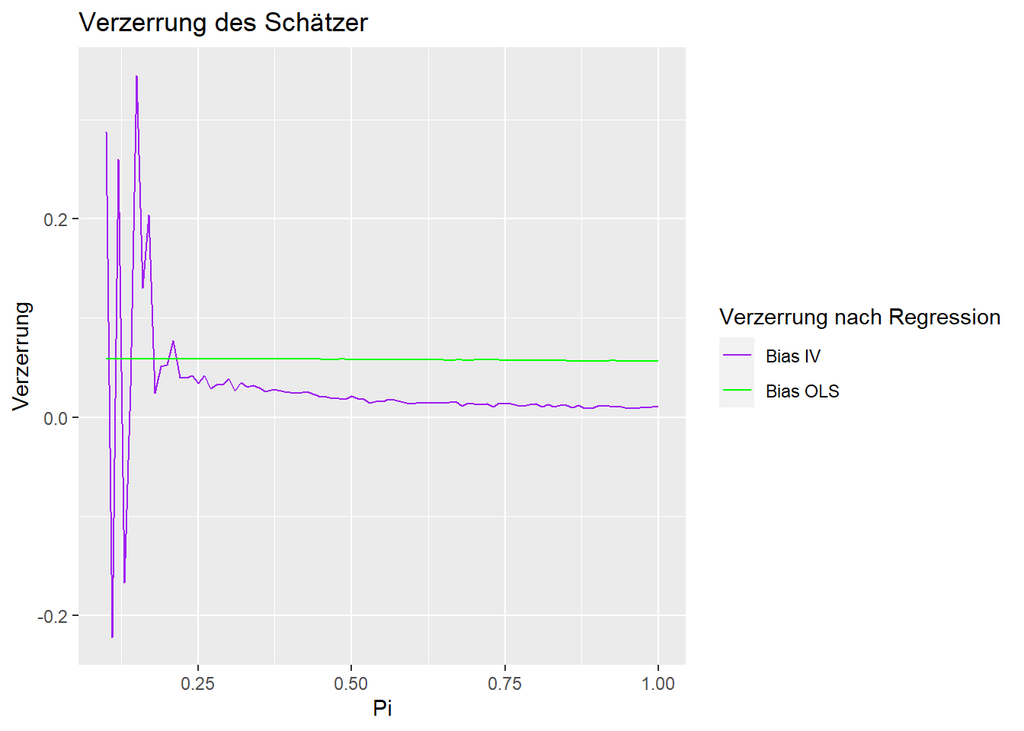

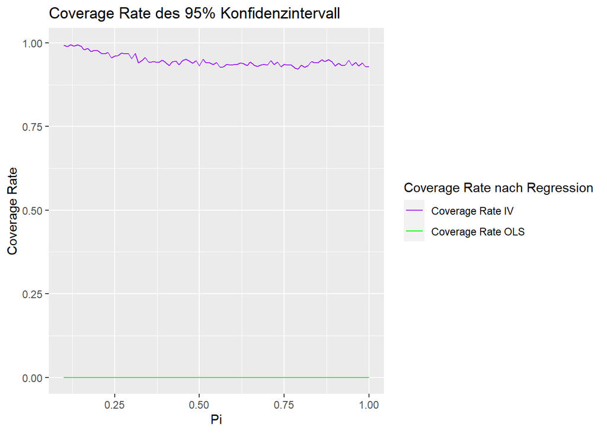

**Beschreibung**:

Der OLS Schätzer ist konstant verzerrt, unabhängig von $\pi$. Wenn $\pi$ zu 1 tendiert, wird der IV Schätzer hingegen asymptotisch unverzerrt.

**Interpretation**:

#### OLS Schätzer

Der OLS Schätzer ist konstant verzerrt, da ein Omitted Variable Bias vorliegt. Dieser kann formal hergeitet werten (Vorlesung 6, slide 7):

$$OVB = \beta_2 \frac{Cov(d,z)}{Var(d)} + \beta_3 \frac{Cov(d,ov)}{Var(d)}$$

In Abhängigkeit von $\pi$:

$$Cov(d,z) = Cov(12 + \pi*z+ 0.5 * ov + \epsilon, z)$$

$$Var(d) = Var(12 + \pi*z+ 0.5 * ov + \epsilon) = E(144 + (\pi*z)^2 + 0.25 * ov^2 + \epsilon^2) - E(12 + \pi*z+ 0.5 * ov + \epsilon)^2$$
$$Var(d) = 0.21\pi + 4.25$$

$\beta_2$ und $\beta_3$ sind gegeben positiv. Die Kovarianzen und die Variationen von $d$ sind auch positiv, wodurch der OLS Bias entsteht. Obwohl die Varianz von $d$ mit $\pi$ steigt, nimmt auch die Kovarianz von $d$ zu mit $\pi$. Also besteht eine *konstante Verzerrung*

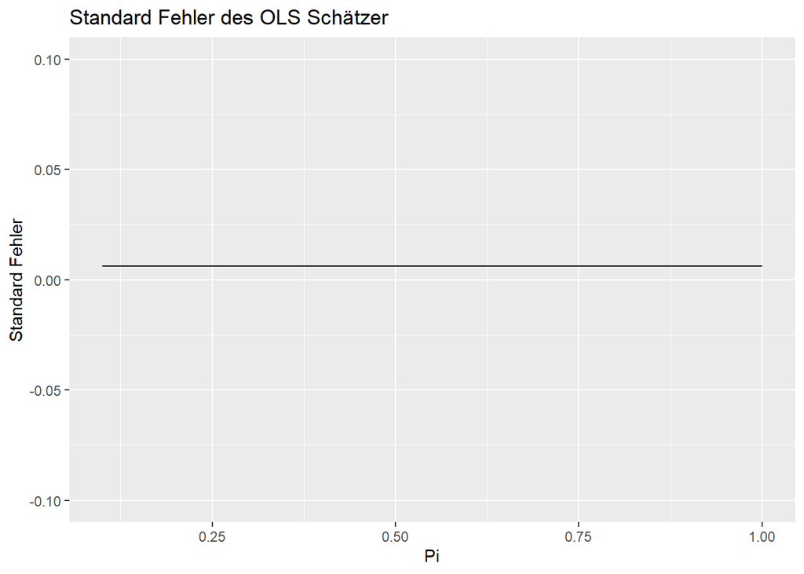

```r
tab3 <- as_tibble(cbind(totSEOLS, pi))

ggplot(data = tab3, aes(y =totSEOLS, x = pi )) +
  geom_line() +
  labs(title =  "Standard Fehler des OLS Schätzer", x = "Pi" , y = "Standard Fehler") +
  ylim(-0.1,0.1)
```

Der Standardfehler des OLS Schätzer ist zu klein und verändert sich nicht durch Pi, weshalb $\beta_1$ nie im Konfidenzintervall liegen wird.

#### IV Schätzer

Der Bias des IV Schätzer ist zuerst sehr gross, da ein kleines $\pi$ ein schwaches Instrument imliziert. Da aber das Instrument immer stärker wird, verschwindet auch der Bias.

Vorlesung 16, Slide 21:
$$plim(\hat{\beta}) = \beta_1 + \frac{Cov(z,u)}{Cov(z,d)}
\rightarrow
OVB = E(\hat{\beta}-\beta) = \frac{Cov(z,u)}{Cov(z,d)}$$
Idealerweise wäre $Cov(z,u) = 0$, jedoch besteht eine kleine Kovariation. Zu Beginn wenn $z$ ein schwaches Instrument für $d$ ist verursacht dies einen kleinen Nenner, was den explosiven Bias am Anfang erklärt. Mit $\pi \rightarrow 1$ wird dieser Nenner jedoch immer grösser und der Bias verschwindet beinahe.

Der Standard Fehler des IV Schätzer wird ebenso minimal(≈ 0) wenn z ein stärkeres Instrument wird. Aufgrund des massiven Standard Fehler am Anfang ist auch die Coverage Rate zu Beginn = 1

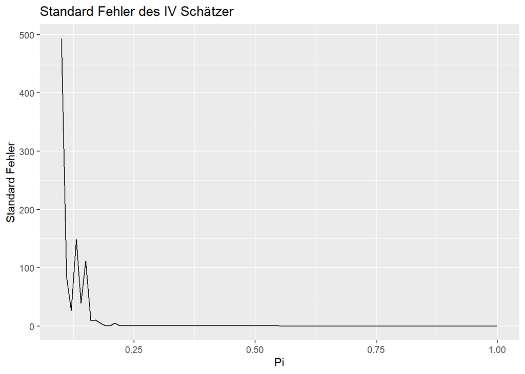

```r
tab4 <- as_tibble(cbind(totSEIV, pi))

ggplot(data = tab4, aes(y = totSEIV, x = pi)) +
  geom_line() +
  labs(title = "Standard Fehler des IV Schätzer", x = "Pi", y = "Standard Fehler")
```

Zusammenfassend wurde gezeigt, dass ein Instrument mit genügender Stärke einen unverzerrten Schätzer generieren kann, jedoch müssen die Annahmen begutachtet werden.